# Working with Databases

Joong-Ho Won

November 01, 2018

## Acknowledgement

Most material in this lecture is adpated from http://www2.stat.duke.edu/~cr173/Sta523_Fa17/sql.html and http://www2.stat.duke.edu/~cr173/Sta523_Fa17/bigish_data.html by Dr. Colin Rundel to handle a bigish data set.

## Introduction

We will learn:

- Import data from a bigish csv file.
- Tidy data.
- Deposit data into an SQLite database.
- Query SQLite database.
- Transform in database and plot in R.

## CSV file

- Source: [NYC Open Data] (https://data.cityofnewyork.us/City-Government/Parking-Violations-Issued-Fiscal-Year-2014-August-/jt7v-77mi) [Kaggle](https://www.kaggle.com/new-york-city/nyc-parking-tickets)

You can create a symbolic link to the data file by Bash command

```bash
ln -sf /home/stat326_621a/data/nyc_parking/NYParkingViolations.csv NYParkingViolations.csv
```

The CSV file is about 1.7GB

```bash
ls -l NYParkingViolations.csv
```

```
## -rwxr-xr-x@ 1 jhwon  staff  1869025315 Oct 26  2017 NYParkingViolations.csv
```

How many rows?

```bash
wc -l NYParkingViolations.csv
```

```
##  9100279 NYParkingViolations.csv
```

First few lines:

```bash
head -5 NYParkingViolations.csv
```

```
## Summons Number,Plate ID,Registration State,Plate Type,Issue Date,Violation Code,Vehicle Body Type,Vehicle Make,Issuing Agency,Street Code1,Street Code2,Street Code3,Vehicle Expiration Date,Violation Location,Violation Precinct,Issuer Precinct,Issuer Code,Issuer Command,Issuer Squad,Violation Time…
## 1283294138,GBB9093,NY,PAS,08/04/2013,46,SUBN,AUDI,P,37250,13610,21190,20140831,0033,33,33,921043,0033,0000,0752A,,,F,712,W 175 ST,,0,408,F1,,BBBBBBB,ALL,ALL,GY,0,2013,-,0,,,,,,,,,,,,,
## 1283294151,62416MB,NY,COM,08/04/2013,46,VAN,FORD,P,37290,40404,40404,20140430,0033,33,33,921043,0033,0000,1240P,,NY,O,201,W 177 ST,,0,408,C,,BBBBBBB,ALL,ALL,WH,0,2012,-,0,,,,,,,,,,,,,
## 1283294163,78755JZ,NY,COM,08/05/2013,46,P-U,CHEVR,P,37030,31190,13610,20140228,0033,33,33,921043,0033,0000,1243P,,NY,O,520,W 163 ST,,0,408,F7,,BBBBBBB,ALL,ALL,,0,0,-,0,,,,,,,,,,,,,
## 1283294175,63009MA,NY,COM,08/05/2013,46,VAN,FORD,P,37270,11710,12010,20141031,0033,33,33,921043,0033,0000,0232P,,NY,O,517,W 176 ST,,0,408,F1,,BBBBBBB,ALL,ALL,WH,0,2010,-,0,,,,,,,,,,,,,
```

## Read csv file

  ```r
  system.time(read.csv("NYParkingViolations.csv"))
  ```

  ```
  ##    user  system elapsed
  ## 223.428  21.170 249.878
  ```

- data.table is an R package for reading large data sets:

  ```r
  library(data.table)
  system.time({nyc = fread("NYParkingViolations.csv")})
  ```

  ```
  ##    user  system elapsed
  ##  47.633   2.359  14.419
  ```

  ```r
  class(nyc)
  ```

  ```
  ## [1] "data.table" "data.frame"
  ```

  ```r
  nyc = as.data.frame(nyc)
  class(nyc)
  ```

  ```
  ## [1] "data.frame"
  ```

- `read_csv()` function in tidyverse is 3-4 times faster than base R:

  ```r
  library("tidyverse")
  system.time({nyc = read_csv("NYParkingViolations.csv")})
  ```

  ```
  ##    user  system elapsed
  ##  56.384   8.228  66.130
  ```

  ```r
  nyc
  ```

  ```
  ## # A tibble: 9,100,278 x 51
  ##    `Summons Number` `Plate ID` `Registration S… `Plate Type` `Issue Date`
  ##               <dbl> <chr>      <chr>            <chr>        <chr>
  ##  1       1283294138 GBB9093    NY               PAS          08/04/2013
  ##  2       1283294151 62416MB    NY               COM          08/04/2013
  ##  3       1283294163 78755JZ    NY               COM          08/05/2013
  ##  4       1283294175 63009MA    NY               COM          08/05/2013
  ##  5       1283294187 91648MC    NY               COM          08/08/2013
  ##  6       1283294217 T60DAR     NJ               PAS          08/11/2013
  ##  7       1283294229 GCR2838    NY               PAS          08/11/2013
  ##  8       1283983620 XZ764G     NJ               PAS          08/07/2013
  ##  9       1283983631 GBH9379    NY               PAS          08/07/2013
  ## 10       1283983667 MCL78B     NJ               PAS          07/18/2013
  ## # ... with 9,100,268 more rows, and 46 more variables: `Violation
  ## #   Code` <int>, `Vehicle Body Type` <chr>, `Vehicle Make` <chr>, `Issuing
  ## #   Agency` <chr>, `Street Code1` <int>, `Street Code2` <int>, `Street
  ## #   Code3` <int>, `Vehicle Expiration Date` <int>, `Violation
  ## #   Location` <chr>, `Violation Precinct` <int>, `Issuer Precinct` <int>,
  ## #   `Issuer Code` <int>, `Issuer Command` <chr>, `Issuer Squad` <chr>,
  ## #   `Violation Time` <chr>, `Time First Observed` <chr>, `Violation
  ## #   County` <chr>, `Violation In Front Of Or Opposite` <chr>, `House
  ## #   Number` <chr>, `Street Name` <chr>, `Intersecting Street` <chr>, `Date
  ## #   First Observed` <int>, `Law Section` <int>, `Sub Division` <chr>,
  ## #   `Violation Legal Code` <int>, `Days Parking In Effect` <chr>, `From
  ## #   Hours In Effect` <chr>, `To Hours In Effect` <chr>, `Vehicle
  ## #   Color` <chr>, `Unregistered Vehicle?` <int>, `Vehicle Year` <int>,
  ## #   `Meter Number` <chr>, `Feet From Curb` <int>, `Violation Post
  ## #   Code` <chr>, `Violation Description` <chr>, `No Standing or Stopping
  ## #   Violation` <chr>, `Hydrant Violation` <chr>, `Double Parking
  ## #   Violation` <chr>, Latitude <chr>, Longitude <chr>, `Community
  ## #   Board` <chr>, `Community Council` <chr>, `Census Tract` <chr>,
  ## #   BIN <chr>, BBL <chr>, NTA <chr>
  ```

## Fix column names

```r
names(nyc) <- str_replace_all(names(nyc), " ", "_")
head(nyc)
```

```
## # A tibble: 6 x 51
##   Summons_Number Plate_ID Registration_St… Plate_Type Issue_Date
##            <dbl> <chr>    <chr>            <chr>      <chr>
## 1     1283294138 GBB9093  NY               PAS        08/04/2013
## 2     1283294151 62416MB  NY               COM        08/04/2013
## 3     1283294163 78755JZ  NY               COM        08/05/2013
## 4     1283294175 63009MA  NY               COM        08/05/2013
## 5     1283294187 91648MC  NY               COM        08/08/2013
## 6     1283294217 T60DAR   NJ               PAS        08/11/2013
## # ... with 46 more variables: Violation_Code <int>,
## #   Vehicle_Body_Type <chr>, Vehicle_Make <chr>, Issuing_Agency <chr>,
## #   Street_Code1 <int>, Street_Code2 <int>, Street_Code3 <int>,
## #   Vehicle_Expiration_Date <int>, Violation_Location <chr>,
## #   Violation_Precinct <int>, Issuer_Precinct <int>, Issuer_Code <int>,
## #   Issuer_Command <chr>, Issuer_Squad <chr>, Violation_Time <chr>,
## #   Time_First_Observed <chr>, Violation_County <chr>,
## #   Violation_In_Front_Of_Or_Opposite <chr>, House_Number <chr>,
## #   Street_Name <chr>, Intersecting_Street <chr>,
## #   Date_First_Observed <int>, Law_Section <int>, Sub_Division <chr>,
## #   Violation_Legal_Code <int>, Days_Parking_In_Effect <chr>,
## #   From_Hours_In_Effect <chr>, To_Hours_In_Effect <chr>,
## #   Vehicle_Color <chr>, `Unregistered_Vehicle?` <int>,
## #   Vehicle_Year <int>, Meter_Number <chr>, Feet_From_Curb <int>,
## #   Violation_Post_Code <chr>, Violation_Description <chr>,
## #   No_Standing_or_Stopping_Violation <chr>, Hydrant_Violation <chr>,
## #   Double_Parking_Violation <chr>, Latitude <chr>, Longitude <chr>,
## #   Community_Board <chr>, Community_Council <chr>, Census_Tract <chr>,
## #   BIN <chr>, BBL <chr>, NTA <chr>
```

## Simplifying

We make a smaller data set with selected variables:

```r
# magrittr for %<>%
library("magrittr")
(nyc %<>%
  select(Registration_State:Issuing_Agency,
         Violation_Location, Violation_Precinct, Violation_Time,
         House_Number:Intersecting_Street, Vehicle_Color))
```

```
## # A tibble: 9,100,278 x 14
##    Registration_St… Plate_Type Issue_Date Violation_Code Vehicle_Body_Ty…
##    <chr>            <chr>      <chr>               <int> <chr>
##  1 NY               PAS        08/04/2013             46 SUBN
##  2 NY               COM        08/04/2013             46 VAN
##  3 NY               COM        08/05/2013             46 P-U
##  4 NY               COM        08/05/2013             46 VAN
##  5 NY               COM        08/08/2013             41 TRLR
##  6 NJ               PAS        08/11/2013             14 P-U
##  7 NY               PAS        08/11/2013             14 VAN
##  8 NJ               PAS        08/07/2013             24 DELV
##  9 NY               PAS        08/07/2013             24 SDN
## 10 NJ               PAS        07/18/2013             24 SDN
## # ... with 9,100,268 more rows, and 9 more variables: Vehicle_Make <chr>,
## #   Issuing_Agency <chr>, Violation_Location <chr>,
## #   Violation_Precinct <int>, Violation_Time <chr>, House_Number <chr>,
## #   Street_Name <chr>, Intersecting_Street <chr>, Vehicle_Color <chr>
```

## Fix dates

Hadley Wickham’s lubridate package facilitates handling date and time. Read [Chapter 16](http://r4ds.had.co.nz/dates-and-times.html) of *R for Data Science* for more information.

Make variable `Issue_Date` of date-time type:

```r
library("lubridate")
class(nyc$Issue_Date)
```

```
## [1] "character"
```

```r
nyc %<>% mutate(Issue_Date = mdy(Issue_Date))
class(nyc$Issue_Date)
```

```
## [1] "Date"
```

```r
nyc
```

```
## # A tibble: 9,100,278 x 14
##    Registration_St… Plate_Type Issue_Date Violation_Code Vehicle_Body_Ty…
##    <chr>            <chr>      <date>              <int> <chr>
##  1 NY               PAS        2013-08-04             46 SUBN
##  2 NY               COM        2013-08-04             46 VAN
##  3 NY               COM        2013-08-05             46 P-U
##  4 NY               COM        2013-08-05             46 VAN
##  5 NY               COM        2013-08-08             41 TRLR
##  6 NJ               PAS        2013-08-11             14 P-U
##  7 NY               PAS        2013-08-11             14 VAN
##  8 NJ               PAS        2013-08-07             24 DELV
##  9 NY               PAS        2013-08-07             24 SDN
## 10 NJ               PAS        2013-07-18             24 SDN
## # ... with 9,100,268 more rows, and 9 more variables: Vehicle_Make <chr>,
## #   Issuing_Agency <chr>, Violation_Location <chr>,
## #   Violation_Precinct <int>, Violation_Time <chr>, House_Number <chr>,
## #   Street_Name <chr>, Intersecting_Street <chr>, Vehicle_Color <chr>
```

Only keep data in years 2013-4.

```r
range(nyc$Issue_Date)
```

```
## [1] "1970-12-18" "2069-12-23"
```

```r
nyc$Issue_Date %>% year() %>% table()
```

```
## .
##    1970    1971    1973    1974    1976    1977    1979    1981    1983
##       1       6      10       1       2       1       2       4       1
##    1984    1987    1990    1991    1996    2000    2001    2002    2003
##       2       3       2       1       1     319      91       7      39
##    2004    2005    2006    2007    2008    2009    2010    2011    2012
##      77       9      11      13       8       9     129     251     618
##    2013    2014    2015    2016    2017    2018    2019    2020    2021
## 4379109 4716512    1522     296     309     181     329      18      26
##    2022    2023    2024    2025    2026    2027    2028    2029    2030
##       1      31      23      10       4       4       7       3      45
##    2031    2032    2033    2040    2041    2043    2044    2045    2046
##      93       3       8       1      39       9       9       2       7
##    2047    2048    2049    2050    2051    2052    2053    2060    2061
##       6       1       3       1      12       2       1       3      10
##    2063    2064    2066    2067    2069
##       9       5       3       2       1
```

```r
filter(nyc, Issue_Date >= mdy("1/1/2013"), Issue_Date <= mdy("12/31/2014"))
```

```
## # A tibble: 9,095,621 x 14
##    Registration_St… Plate_Type Issue_Date Violation_Code Vehicle_Body_Ty…
##    <chr>            <chr>      <date>              <int> <chr>
##  1 NY               PAS        2013-08-04             46 SUBN
##  2 NY               COM        2013-08-04             46 VAN
##  3 NY               COM        2013-08-05             46 P-U
##  4 NY               COM        2013-08-05             46 VAN
##  5 NY               COM        2013-08-08             41 TRLR
##  6 NJ               PAS        2013-08-11             14 P-U
##  7 NY               PAS        2013-08-11             14 VAN
##  8 NJ               PAS        2013-08-07             24 DELV
##  9 NY               PAS        2013-08-07             24 SDN
## 10 NJ               PAS        2013-07-18             24 SDN
## # ... with 9,095,611 more rows, and 9 more variables: Vehicle_Make <chr>,
## #   Issuing_Agency <chr>, Violation_Location <chr>,
## #   Violation_Precinct <int>, Violation_Time <chr>, House_Number <chr>,
## #   Street_Name <chr>, Intersecting_Street <chr>, Vehicle_Color <chr>
```

## Putting it all together

```r
system.time({
  nyc <- read_csv("NYParkingViolations.csv") %>%
    setNames(str_replace_all(names(.)," ", "_")) %>%
    select(Registration_State:Issuing_Agency,
         Violation_Location, Violation_Precinct, Violation_Time,
         House_Number:Intersecting_Street, Vehicle_Color) %>%
    mutate(Issue_Date = mdy(Issue_Date)) %>%
    mutate(Issue_Day = day(Issue_Date),
           Issue_Month = month(Issue_Date),
           Issue_Year = year(Issue_Date),
           Issue_WDay = wday(Issue_Date, label=TRUE)) %>%
    filter(Issue_Year %in% 2013:2014)
})
```

```
##    user  system elapsed
##  59.294   8.080  68.867
```

```r
nyc
```

```
## # A tibble: 9,095,621 x 18
##    Registration_St… Plate_Type Issue_Date Violation_Code Vehicle_Body_Ty…
##    <chr>            <chr>      <date>              <int> <chr>
##  1 NY               PAS        2013-08-04             46 SUBN
##  2 NY               COM        2013-08-04             46 VAN
##  3 NY               COM        2013-08-05             46 P-U
##  4 NY               COM        2013-08-05             46 VAN
##  5 NY               COM        2013-08-08             41 TRLR
##  6 NJ               PAS        2013-08-11             14 P-U
##  7 NY               PAS        2013-08-11             14 VAN
##  8 NJ               PAS        2013-08-07             24 DELV
##  9 NY               PAS        2013-08-07             24 SDN
## 10 NJ               PAS        2013-07-18             24 SDN
## # ... with 9,095,611 more rows, and 13 more variables: Vehicle_Make <chr>,
## #   Issuing_Agency <chr>, Violation_Location <chr>,
## #   Violation_Precinct <int>, Violation_Time <chr>, House_Number <chr>,
## #   Street_Name <chr>, Intersecting_Street <chr>, Vehicle_Color <chr>,
## #   Issue_Day <int>, Issue_Month <dbl>, Issue_Year <dbl>, Issue_WDay <ord>
```

## Ticket frequency

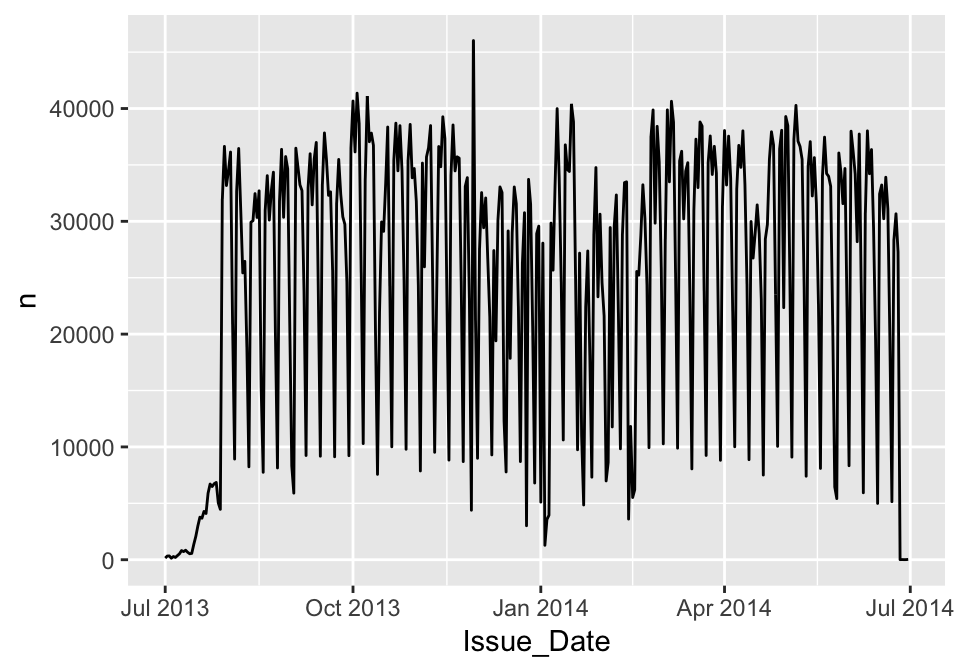

```r
nyc %>%
  group_by(Issue_Date) %>%
  summarize(n = n()) %>%
  ggplot(aes(x = Issue_Date, y = n)) +
    geom_line() +
    xlim(mdy("7/1/2013"), mdy("6/30/2014"))
```

## Create an SQLite database

Import the `nyc` data set into the SQLite database:

```r
library("DBI")
library("RSQLite")
library("tidyverse")
if (Sys.info()[["sysname"]] == "Linux") {
  db <- dbConnect(RSQLite::SQLite(),
                  dbname = "/home/stat326_621a/data/nyc_parking/NYParkingViolations.sqlite")
} else if (Sys.info()[["sysname"]] == "Darwin") {
  db <- dbConnect(RSQLite::SQLite(),
                  dbname = "./NYParkingViolations.sqlite")
}
dbWriteTable(db, "nyc", nyc, overwrite = TRUE)
dbListTables(db)
```

```
## [1] "nyc"
```

```r
dbDisconnect(db)
```

You can create a symbolic link to the database file by Bash command

```bash
ln -sf /home/stat326_621a/data/nyc_parking/NYParkingViolations.sqlite NYParkingViolations.sqlite
```

Size of the database file

```bash
ls -l NYParkingViolations.sqlite
```

```
## -rw-r--r--@ 1 jhwon  staff  731770880 Nov  1 11:06 NYParkingViolations.sqlite
```

## Read data from database

Connect to table in database:

```r
db <- dbConnect(RSQLite::SQLite(), dbname = "./NYParkingViolations.sqlite")
dbListTables(db)
```

```
## [1] "nyc"
```

```r
nyc_sql <- dplyr::tbl(db, "nyc")
str(nyc_sql)
```

```
## List of 2
##  $ src:List of 2
##   ..$ con  :Formal class 'SQLiteConnection' [package "RSQLite"] with 7 slots
##   .. .. ..@ ptr                :<externalptr>
##   .. .. ..@ dbname             : chr "/Users/jhwon/Dropbox/class/326.621A/2018/datasci/lectures/11-dbplyr/NYParkingViolations.sqlite"
##   .. .. ..@ loadable.extensions: logi TRUE
##   .. .. ..@ flags              : int 70
##   .. .. ..@ vfs                : chr ""
##   .. .. ..@ ref                :<environment: 0x7fbeb1eee9a8>
##   .. .. ..@ bigint             : chr "integer64"
##   ..$ disco: NULL
##   ..- attr(*, "class")= chr [1:3] "src_dbi" "src_sql" "src"
##  $ ops:List of 2
##   ..$ x   : 'ident' chr "nyc"
##   ..$ vars: chr [1:18] "Registration_State" "Plate_Type" "Issue_Date" "Violation_Code" ...
##   ..- attr(*, "class")= chr [1:3] "op_base_remote" "op_base" "op"
##  - attr(*, "class")= chr [1:4] "tbl_dbi" "tbl_sql" "tbl_lazy" "tbl"
```

```r
nyc_sql %>% print(width = Inf)
```

```
## # Source:   table<nyc> [?? x 18]
## # Database: sqlite 3.22.0
## #   [/Users/jhwon/Dropbox/class/326.621A/2018/datasci/lectures/11-dbplyr/NYParkingViolations.sqlite]
##    Registration_State Plate_Type Issue_Date Violation_Code
##    <chr>              <chr>           <dbl>          <int>
##  1 NY                 PAS             15921             46
##  2 NY                 COM             15921             46
##  3 NY                 COM             15922             46
##  4 NY                 COM             15922             46
##  5 NY                 COM             15925             41
##  6 NJ                 PAS             15928             14
##  7 NY                 PAS             15928             14
##  8 NJ                 PAS             15924             24
##  9 NY                 PAS             15924             24
## 10 NJ                 PAS             15904             24
```

[output cut: 49 more lines]

## Use dplyr with SQLite

```r
addr <- nyc_sql %>%
  select(Issue_Date, Issuing_Agency, Violation_Precinct, House_Number, Street_Name) %>%
  filter(Violation_Precinct >= 1, Violation_Precinct <= 34)
addr
```

```
## # Source:   lazy query [?? x 5]
## # Database: sqlite 3.22.0
## #   [/Users/jhwon/Dropbox/class/326.621A/2018/datasci/lectures/11-dbplyr/NYParkingViolations.sqlite]
##    Issue_Date Issuing_Agency Violation_Precin… House_Number Street_Name
##         <dbl> <chr>                      <int> <chr>        <chr>
##  1      15921 P                             33 712          W 175 ST
##  2      15921 P                             33 201          W 177 ST
##  3      15922 P                             33 520          W 163 ST
##  4      15922 P                             33 517          W 176 ST
##  5      15925 P                             33 590          W 174 ST
##  6      15928 P                             33 525          W 175 ST
##  7      15928 P                             33 551          W 175 ST
##  8      15891 P                             13 59           W 21 STREET
##  9      15906 T                             28 <NA>         N/S WILLOUGHB…
## 10      15904 T                              1 <NA>         <NA>
## # ... with more rows
```

## SQL query

```r
class(addr)
```

```
## [1] "tbl_dbi"  "tbl_sql"  "tbl_lazy" "tbl"
```

```r
show_query(addr)
```

```
## <SQL>
## SELECT *
## FROM (SELECT `Issue_Date`, `Issuing_Agency`, `Violation_Precinct`, `House_Number`, `Street_Name`
## FROM `nyc`)
## WHERE ((`Violation_Precinct` >= 1.0) AND (`Violation_Precinct` <= 34.0))
```

## Mutate and summarise

```r
addr %>% mutate(address = paste(House_Number, Street_Name))
```

```
## # Source:   lazy query [?? x 6]
## # Database: sqlite 3.22.0
## #   [/Users/jhwon/Dropbox/class/326.621A/2018/datasci/lectures/11-dbplyr/NYParkingViolations.sqlite]
##    Issue_Date Issuing_Agency Violation_Preci… House_Number Street_Name
##         <dbl> <chr>                     <int> <chr>        <chr>
##  1      15921 P                            33 712          W 175 ST
##  2      15921 P                            33 201          W 177 ST
##  3      15922 P                            33 520          W 163 ST
##  4      15922 P                            33 517          W 176 ST
##  5      15925 P                            33 590          W 174 ST
##  6      15928 P                            33 525          W 175 ST
##  7      15928 P                            33 551          W 175 ST
##  8      15891 P                            13 59           W 21 STREET
##  9      15906 T                            28 <NA>         N/S WILLOU…
## 10      15904 T                             1 <NA>         <NA>
## # ... with more rows, and 1 more variable: address <chr>
```

```r
addr %>% summarize(mean = mean(Violation_Precinct, na.rm = TRUE))
```

```
## # Source:   lazy query [?? x 1]
## # Database: sqlite 3.22.0
## #   [/Users/jhwon/Dropbox/class/326.621A/2018/datasci/lectures/11-dbplyr/NYParkingViolations.sqlite]
##    mean
##   <dbl>
## 1  16.1
```

## SQL grouping

```r
addr %>%
  group_by(Issuing_Agency, Violation_Precinct) %>%
  summarize(n = n())
```

```
## # Source:   lazy query [?? x 3]
## # Database: sqlite 3.22.0
## #   [/Users/jhwon/Dropbox/class/326.621A/2018/datasci/lectures/11-dbplyr/NYParkingViolations.sqlite]
## # Groups:   Issuing_Agency
##    Issuing_Agency Violation_Precinct     n
##    <chr>                       <int> <int>
##  1 A                               1    13
##  2 A                               7     1
##  3 A                              10    24
##  4 A                              11     1
##  5 A                              14    47
##  6 A                              33    11
##  7 B                              25     2
##  8 C                               5    73
##  9 C                              13     7
## 10 D                               1     1
## # ... with more rows
```

## SQL query

```r
addr %>%
  group_by(Issuing_Agency, Violation_Precinct) %>%
  summarize(n = n()) %>%
  show_query()
```

```
## <SQL>
## SELECT `Issuing_Agency`, `Violation_Precinct`, COUNT() AS `n`
## FROM (SELECT `Issue_Date`, `Issuing_Agency`, `Violation_Precinct`, `House_Number`, `Street_Name`
## FROM `nyc`)
## WHERE ((`Violation_Precinct` >= 1.0) AND (`Violation_Precinct` <= 34.0))
## GROUP BY `Issuing_Agency`, `Violation_Precinct`
```

## SQL translation

dbplyr package (a dplyr backend for databases) has a function, `translate_sql`, that lets you experiment with how R functions are translated to SQL:

```r
library("dbplyr")
translate_sql(x == 1 & (y < 2 | z > 3))
```

```
## <SQL> "x" = 1.0 AND ("y" < 2.0 OR "z" > 3.0)
```

```r
translate_sql(x ^ 2 < 10)
```

```
## <SQL> POWER("x", 2.0) < 10.0
```

```r
translate_sql(x %% 2 == 10)
```

```
## <SQL> "x" % 2.0 = 10.0
```

```r
translate_sql(paste(x, y))
```

```
## <SQL> PASTE("x", "y")
```

```r
translate_sql(mean(x))
```

```
## <SQL> avg("x") OVER ()
```

```r
translate_sql(mean(x, na.rm = TRUE))
```

```
## <SQL> avg("x") OVER ()
```

## Timings

dplyr using tibble:

```r
system.time(
  nyc %>%
    select(Issue_Date, Issuing_Agency, Violation_Precinct, House_Number, Street_Name) %>%
    filter(Violation_Precinct >=1, Violation_Precinct <= 34) %>%
    group_by(Issuing_Agency, Violation_Precinct) %>%
    summarize(n = n())
)
```

```
##    user  system elapsed
##   0.340   0.090   0.436
```

dplyr using SQLite:

```r
system.time(
  nyc_sql %>%
    select(Issue_Date, Issuing_Agency, Violation_Precinct, House_Number, Street_Name) %>%
    filter(Violation_Precinct >=1, Violation_Precinct <= 34) %>%
    group_by(Issuing_Agency, Violation_Precinct) %>%
    summarize(n = n())
)
```

```
##    user  system elapsed
##   0.005   0.000   0.004
```

## Laziness

dplyr/dbplyr uses lazy evaluation as much as possible, particularly when working with non-local backends.

- When building a query, we don’t want the entire table, often we want just enough to check if our query is working.
- Since we would prefer to run one complex query over many simple queries, laziness allows for verbs to be strung together.
- Therefore, by default dplyr
  - won’t connect and query the database until absolutely necessary (e.g. show output),
  - and unless explicitly told to, will only query a handful of rows to give a sense of what the result will look like

```r
nyc_sql %>%
  select(Issue_Date, Issuing_Agency, Violation_Precinct, House_Number, Street_Name) %>%
  filter(Violation_Precinct >=1, Violation_Precinct <= 34) %>%
  group_by(Issuing_Agency, Violation_Precinct) %>%
  summarize(n = n())
```

```
## # Source:   lazy query [?? x 3]
## # Database: sqlite 3.22.0
## #   [/Users/jhwon/Dropbox/class/326.621A/2018/datasci/lectures/11-dbplyr/NYParkingViolations.sqlite]
## # Groups:   Issuing_Agency
##    Issuing_Agency Violation_Precinct     n
##    <chr>                       <int> <int>
##  1 A                               1    13
##  2 A                               7     1
##  3 A                              10    24
##  4 A                              11     1
##  5 A                              14    47
##  6 A                              33    11
##  7 B                              25     2
##  8 C                               5    73
##  9 C                              13     7
## 10 D                               1     1
## # ... with more rows
```

## Full query

To force a full query and return a complete table it is necessary to use the `collect` function.

```r
system.time(
  nyc_sql %>%
    select(Issue_Date, Issuing_Agency, Violation_Precinct, House_Number, Street_Name) %>%
    filter(Violation_Precinct >=1, Violation_Precinct <= 34) %>%
    group_by(Issuing_Agency, Violation_Precinct) %>%
    summarize(n = n()) %>%
    collect()
)
```

```
##    user  system elapsed
##   3.453   0.341   3.830
```

## Plotting

### Bar plot

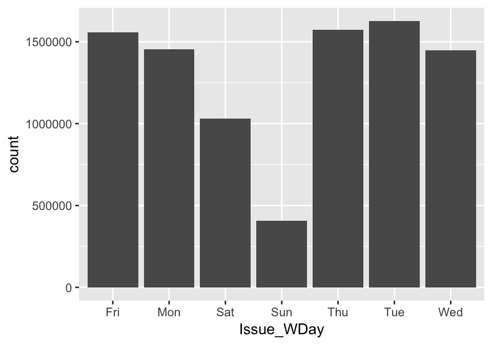

```r
nyc_sql %>%
  ggplot() +
    geom_bar(aes(x = Issue_WDay))
```

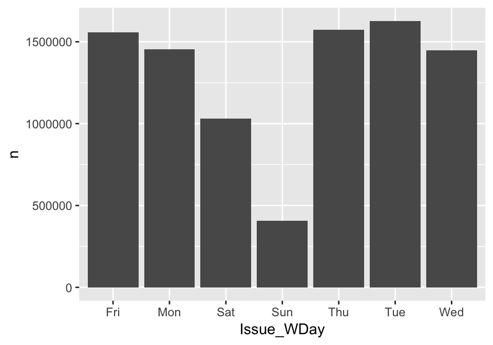

```r
nyc_sql %>%
  group_by(Issue_WDay) %>%
  count() %>%
  collect() %>%
  ggplot() +
    geom_col(aes(x = Issue_WDay, y = n))
```

### Other plots

For example of making histogram and raster plot, read tutorial https://db.rstudio.com/best-practices/visualization/.

## Close connection to database

```r
dbDisconnect(db)
```